# Applied ML - 2019 (Day 2)

Josh Muncke

Jan 15 - Jan 16, 2019

```r
library(tidymodels)
library(tidyverse)
library(ggrepel)

library(AmesHousing)
library(skimr)
library(ggridges)

theme_set(theme_bw())
```

# Day 2

## Setup

Download the cars data set for regression problems…

```r
url <- "https://github.com/topepo/cars/raw/master/2018_12_02_city/car_data_splits.RData"
temp_save <- tempfile()
download.file(url, destfile = temp_save)
load(temp_save)

car_train %>% bind_rows(car_test) %>% group_by(year) %>% count()
```

```
## # A tibble: 5 x 2
## # Groups:   year [5]
##    year     n
##   <int> <int>
## 1  2015  1277
## 2  2016   758
## 3  2017   846
## 4  2018   715
## 5  2019   613
```

Remove some cars from the data set - mainly the non-combustion engines.

```r
removals <- c("CNG", "Electricity")

car_train <-
  car_train %>%
  dplyr::filter(!(fuel_type %in% removals)) %>%
  mutate(fuel_type = relevel(fuel_type, "Gasoline_or_natural_gas"))

car_test <-
  car_test %>%
  dplyr::filter(!(fuel_type %in% removals)) %>%
  mutate(fuel_type = relevel(fuel_type, "Gasoline_or_natural_gas"))
```

Some simple exploration on the data.

```r
skim(car_train)
```

```
## Skim summary statistics
##  n obs: 3526
##  n variables: 30
##
## -- Variable type:factor ---------------------------------------------------------------------------------------------------------------------------
##      variable missing complete    n n_unique
##     car_class       0     3526 3526       22
##         drive       0     3526 3526        6
##     fuel_type       0     3526 3526       11
##          make       0     3526 3526       49
##         model       0     3526 3526     1305
##  transmission       0     3526 3526       31
##                               top_counts ordered
##   Mid: 564, Com: 562, Sub: 357, Sma: 310   FALSE
##  Fro: 1107, Rea: 997, All: 916, fou: 408   FALSE
##  Pre: 1626, Reg: 1524, Gas: 167, Die: 96   FALSE
##   BMW: 341, For: 290, Che: 263, Mer: 251   FALSE
##       Cam: 26, Mus: 21, Jet: 19, Foc: 18   FALSE
##   Aut: 727, Aut: 661, Man: 422, Aut: 284   FALSE
##
## -- Variable type:integer --------------------------------------------------------------------------------------------------------------------------
##            variable missing complete    n    mean    sd   p0  p25  p50
##   four_door_lug_vol       0     3526 3526    5.72  8.18    0    0    0
##  four_door_pass_vol       0     3526 3526   36.26 47.73    0    0    0
##       hatch_lug_vol       0     3526 3526    1.7   5.51    0    0    0
##       hatch_pas_vol       0     3526 3526    8.55 26.51    0    0    0
##    two_door_lug_vol       0     3526 3526    1.53  3.73    0    0    0
##   two_door_pass_vol       0     3526 3526   13.25 30.61    0    0    0
##                year       0     3526 3526 2016.28  1.14 2015 2015 2016
##   p75 p100     hist
##    13   42 ▇▁▂▁▁▁▁▁
##    96  128 ▇▁▁▁▁▂▂▁
##     0   34 ▇▁▁▁▁▁▁▁
##     0  108 ▇▁▁▁▁▁▁▁
##     0   19 ▇▁▁▁▁▁▁▁
##     0  102 ▇▁▁▁▁▁▁▁
##  2017 2018 ▇▁▅▁▁▅▁▅
##
## -- Variable type:numeric --------------------------------------------------------------------------------------------------------------------------
##                        variable missing complete    n     mean    sd   p0
```

[output cut: 20 more lines]

```
##   2     3    3.7    8.4  ▁▇▅▃▂▂▁▁
##   0     0    0      1    ▇▁▁▁▁▁▁▁
##   0     0    0      1    ▇▁▁▁▁▁▁▁
##   0     0    0      1    ▇▁▁▁▁▁▁▁
##   0     0    0      1    ▇▁▁▁▁▁▁▁
##  16.68 19.9 23.81 145.08 ▇▂▁▁▁▁▁▁
##   0     0    0      1    ▇▁▁▁▁▁▁▁
##   0     0    0      1    ▇▁▁▁▁▁▁▁
##   0     0    0      1    ▇▁▁▁▁▁▁▁
##   0     1    1      1    ▃▁▁▁▁▁▁▇
##   0     0    1      1    ▇▁▁▁▁▁▁▅
##   0     0    0      1    ▇▁▁▁▁▁▁▁
##   0     0    1      1    ▇▁▁▁▁▁▁▇
##   0     0    0      1    ▇▁▁▁▁▁▁▁
##   0     0    0      0    ▁▁▁▇▁▁▁▁
```

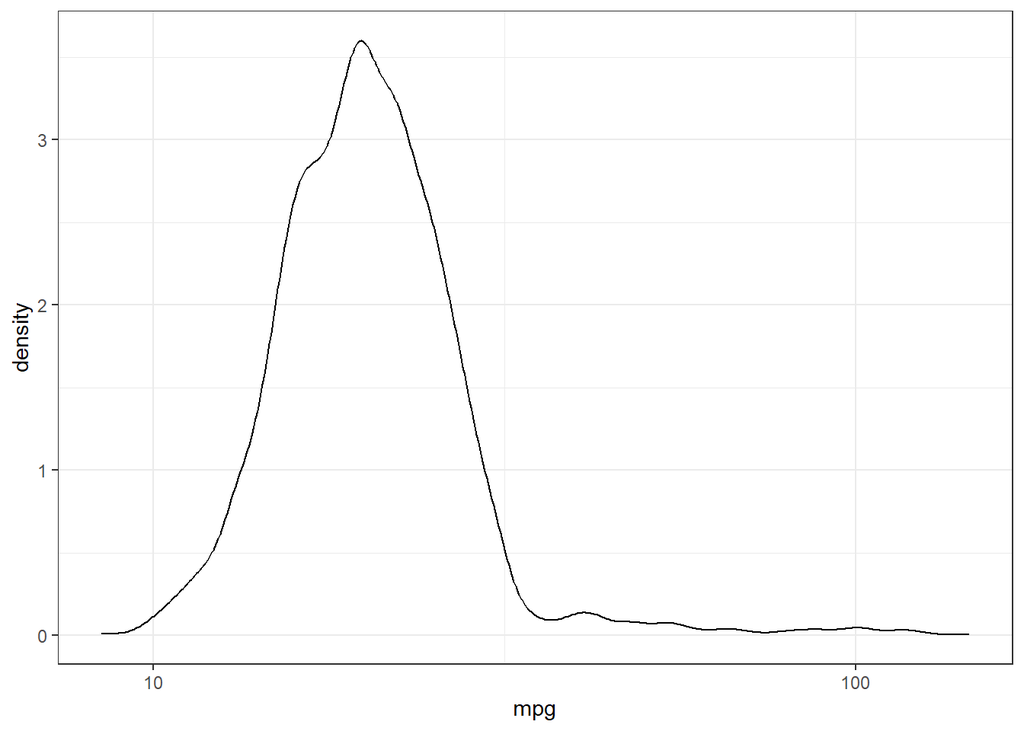

```r
car_train %>%
  ggplot(aes(x = mpg, colour = year)) +
  geom_line(stat = "density") +
  scale_x_log10()
```

## Linear models

Reminder that “linear” in linear models means that your model is linear in the parameters. Non-linear terms can be added without issues, examples:

```r
library(splines)
lm(mpg ~ . -model + ns(eng_displ, 4) + ns(cylinders, 4), data = car_train)
```

```
##
## Call:
## lm(formula = mpg ~ . - model + ns(eng_displ, 4) + ns(cylinders,
##     4), data = car_train)
##
## Coefficients:
##                                 (Intercept)
##                                   12.236736
##                                   cylinders
##                                   -0.514788
##                                   eng_displ
##                                   -1.819573
##                           driveAutomatic_A1
##                                    7.658863
##                        drivefourWheel_Drive
##                                    0.543495
##                       driveFrontWheel_Drive
##                                    1.912487
##               driveParttime_fourWheel_Drive
##                                   -0.284493
##                        driveRearWheel_Drive
##                                    0.678635
##                             fuel_typeDiesel
##                                    7.452293
##                    fuel_typeGasoline_or_E85
##                                    2.711965
##                           fuel_typeMidgrade
##                                    2.816741
##                            fuel_typePremium
##                                    1.913378
##            fuel_typePremium_and_Electricity
##                                   38.056722
##         fuel_typePremium_Gas_or_Electricity
##                                   43.622618
##                     fuel_typePremium_or_E85
##                                    2.115573
##                            fuel_typeRegular
##                                    2.163452
##        fuel_typeRegular_Gas_and_Electricity
##                                   69.340018
```

[output cut: 243 more lines]

```
##                                  -13.293851
##                           ns(eng_displ, 4)2
##                                   -9.166624
##                           ns(eng_displ, 4)3
##                                  -23.602668
##                           ns(eng_displ, 4)4
##                                          NA
##                           ns(cylinders, 4)1
##                                   -1.941019
##                           ns(cylinders, 4)2
##                                    0.129501
##                           ns(cylinders, 4)3
##                                   -2.503802
##                           ns(cylinders, 4)4
##                                          NA
```

With `recipes` - every column has a *role*. By default the variable on the left-hand side of th `~` will be considered an `outcome`, everything else will a `predictor`.

Problem is that if we want to *keep* variables that do not have a role in the recipe…we need to give them a new role.

Here’s a `recipe` for the cars data.

```r
basic_rec <- recipe(mpg ~ ., data = car_train) %>%
  # keep the car name but don't use as a predictor
  update_role(model, new_role = "model") %>%
  # collapse some makes into "other"
  step_other(make, car_class, threshold = 0.005) %>%
  step_other(fuel_type, threshold = 0.01) %>%
  step_dummy(all_nominal(), -model) %>%
  step_zv(all_predictors())

basic_rec
```

```
## Data Recipe
##
## Inputs:
##
##       role #variables
##      model          1
##    outcome          1
##  predictor         28
##
## Operations:
##
## Collapsing factor levels for make, car_class
## Collapsing factor levels for fuel_type
## Dummy variables from all_nominal(), -model
## Zero variance filter on all_predictors()
```

## Elastic Net

We are going to use an Elastic Net model to predict on this dataset.

*Reminder:* using a an L1 and L2 penalty. `lambda` is the regularization strength, `alpha` is the mixing term. They need to be *tuned*.

Need to make sure we appropriately center and scale data.

### Grid search for `glmnet` parameters

Create a tuning parameter grid using `expand.grid`.

```r
alpha_range <- seq(0, 1, by = 0.25)
lambda_range <- 10^seq(-4, -1, length = 20)

glmn_grid <- expand.grid(alpha = alpha_range, lambda = lambda_range)

nrow(glmn_grid) # 100 combinations / different models
```

```
## [1] 100
```

## `caret` basics

- `train` takes a model formula, `recipe` object or (`x`/`y` specification)
- `method` specifies the type of model to fit
- `tuneGrid` lets you specify a tuning grid and takes account of optimizations in the training process automatically (submodel trick)
- `trainControl` how much (and how) should we resample the data to create the model?
- Use `set.seed` right before the call to `train`.

### Fitting using `caret::train`

Create some non-linearity using `recipes`.

```r
library(caret)
ctrl <- trainControl(
  method = "cv",
  # Save the assessment predictions from the best model
  savePredictions = "final",
  # Log the progress of the tuning process
  verboseIter = TRUE
  )

glmn_rec <- basic_rec %>%
  step_center(all_predictors()) %>%
  step_scale(all_predictors()) %>%
  step_ns(eng_displ, cylinders, options = list(df = 4))


set.seed(92598)

glmn_mod <- train(
  glmn_rec,
  data = car_train,
  method = "glmnet",
  trControl = ctrl,
  tuneGrid = glmn_grid
  )
```

```
## Preparing recipe
```

Let’s take a look at the caret results…

```r
glmn_mod$bestTune
```

```
##    alpha     lambda
## 31  0.25 0.00379269
```

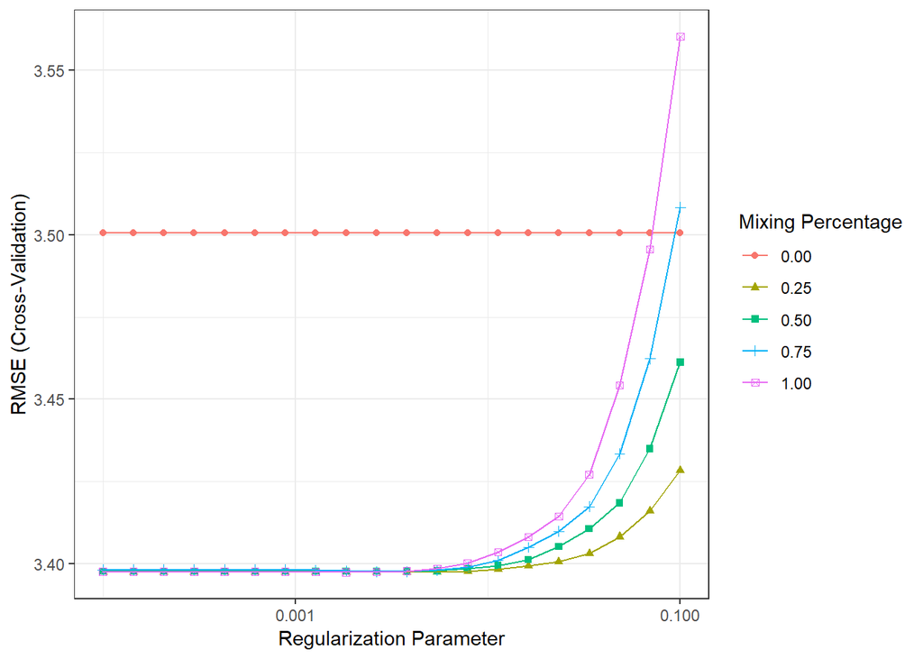

```r
ggplot(glmn_mod) + scale_x_log10()
```

Helper functions for plotting results:

```r
add_columns <- function(x, dat, ...) {
  # capture any selectors and filter the data
  dots <- quos(...)
  if (!is_empty(dots))
    dat <- dplyr::select(dat, year, model, !!!dots)
  dat <-
    x %>%
    pluck("pred") %>%
    arrange(rowIndex) %>%
    dplyr::select(-rowIndex) %>%
    bind_cols(dat)
  # create a label column when possible
  if (all(c("model", "year") %in% names(dat)))
    dat <-
    dat %>%
    mutate(plot_label = paste(year, model))
  dat
}

obs_pred_plot <- function(x, dat, cutoff = 25, ...) {
    pred_dat <- x %>%
      add_columns(dat, model, year) %>%
      mutate(residuals = obs - pred)
    ggplot(pred_dat, aes(x = pred, y = obs)) +
      geom_abline(col = "green", alpha = .5) +
      geom_point(alpha = .3) +
      geom_smooth(
        se = FALSE, col = "red",
        lty = 2, lwd = .25, alpha = .5
      ) +
      geom_text_repel(
        data = dplyr::filter(pred_dat, abs(residuals) > cutoff),
        aes(label = plot_label),
        segment.color = "grey50"
      )
}

resid_plot <- function(x, dat, cutoff = 25, ...) {
    pred_dat <- x %>%
      add_columns(dat, model, year) %>%
      mutate(residuals = obs - pred)
    ggplot(pred_dat, aes(x = pred, y = residuals)) +
      geom_hline(col = "green", yintercept = 0) +
      geom_point(alpha = .3) +
      geom_text_repel(
        data = dplyr::filter(
          pred_dat,
          abs(residuals) > cutoff
        ),
        aes(label = plot_label),
        segment.color = "grey50"
      )
  }
```

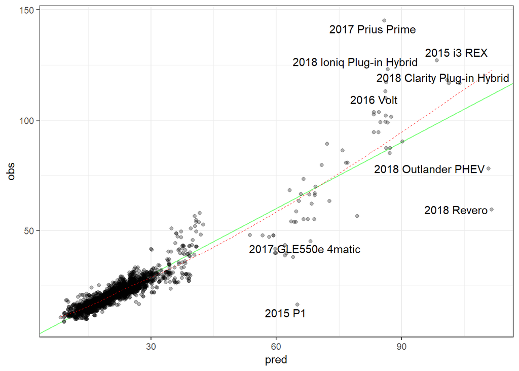

```r
obs_pred_plot(glmn_mod, car_train)
```

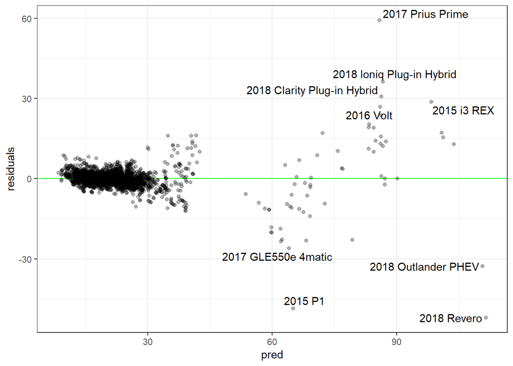

```r
resid_plot(glmn_mod, car_train)
```

Examine variable importance. `caret` knows how to pull them from the model:

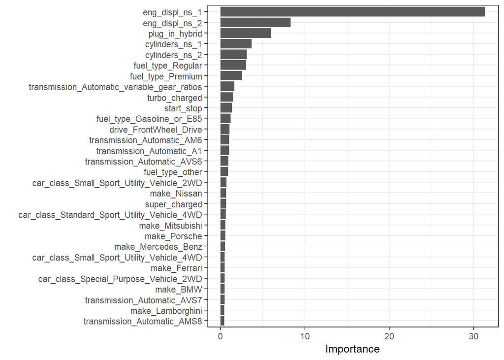

```r
reg_imp <- varImp(glmn_mod, scale = FALSE)
ggplot(reg_imp, top = 30) + xlab("")
```

`predict`ing using `caret`…

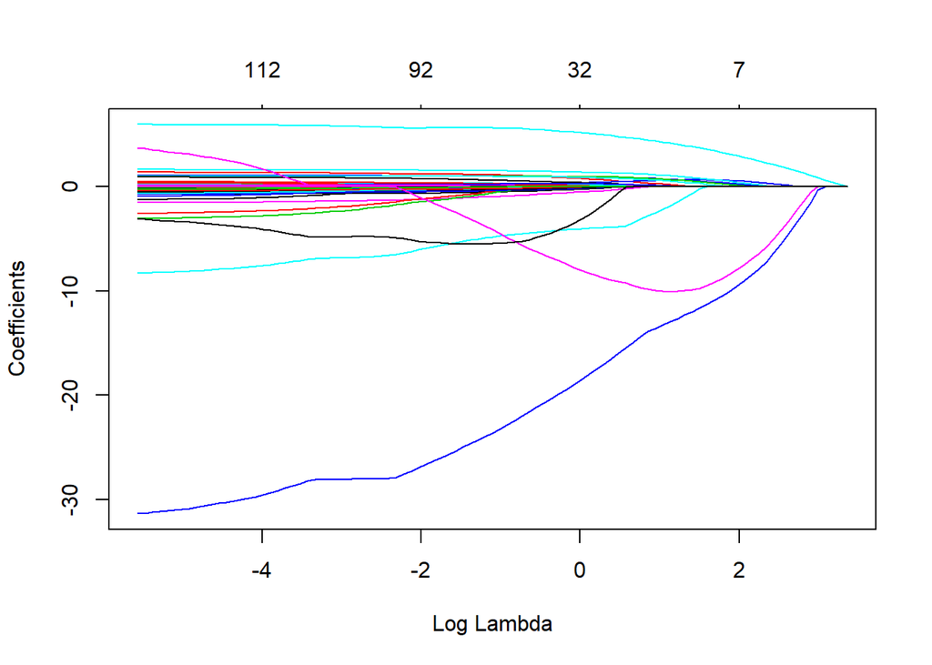

```r
plot(glmn_mod$finalModel, xvar = "lambda")
```

There’s a `finalModel` object within the model object that contains the final object *DO NOT USE `predict` ON THIS OBJECT!* Instead use `predict` on the object produced by `train`…

*NO* : `predict(glmn_mod$finalModel, ...)` *YES* : `predict(glmn_mod, ...)`

Some magic plotting functions for `glmnet` objects.

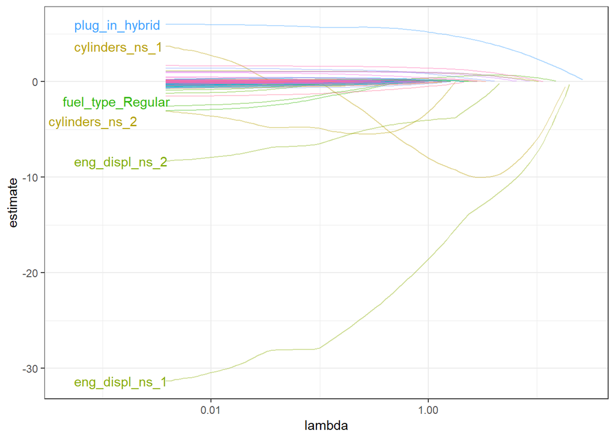

```r
# Get the set of coefficients across penalty values
tidy_coefs <- broom::tidy(glmn_mod$finalModel) %>%
  dplyr::filter(term != "(Intercept)") %>%
  dplyr::select(-step, -dev.ratio)
# Get the lambda closest to caret's optimal choice
delta <- abs(tidy_coefs$lambda - glmn_mod$bestTune$lambda)
lambda_opt <- tidy_coefs$lambda[which.min(delta)]
# Keep the large values
label_coefs <- tidy_coefs %>%
  mutate(abs_estimate = abs(estimate)) %>%
  dplyr::filter(abs_estimate >= 3) %>%
  distinct(term) %>%
  inner_join(tidy_coefs, by = "term") %>%
  dplyr::filter(lambda == lambda_opt)
# plot the paths and highlight the large values
tidy_coefs %>%
  ggplot(aes(x = lambda, y = estimate, group = term, col = term, label = term)) +
  geom_line(alpha = .4) +
  theme(legend.position = "none") +
  scale_x_log10() +
  geom_text_repel(data = label_coefs, aes(x = .0005))
```

## MARS - Multivariate Adaptive Regression Splines

Non-linear ML model develops sequential sets of artificial features based on hinge-functions/single-knot splines. It’s basically a form of segmented regression.

There’s a left and right handed hinge-function which each model different sides of the data.

N.B. a hinge-function is the same as a ReLU.

There’s a “growing” and “pruning” phase. MARS actually can do the selection phase internally using Generalized Cross Validation (faster) but we will also do it via CV in caret because it allows us to examine relationships between performance and model complexity.

Mars also does feature selection apparently. Interesting stuff.

Best MARS implementation is through the `earth` package. Through `caret` we can use `method = "earth"` which uses external resampling and the sub-model trick. We can tune `nprune` (number of retained features) and `degree` (amount fo interaction allowed).

By the way, `caret` supports parallel…`parallel::detectCores(logical = FALSE)`

```r
# library(doParallel)
# cl <- makeCluster

ctrl$verboseIter <- TRUE

mars_grid <- expand.grid(degree = 1:2,
                         nprune = seq(2, 26, by = 2))

set.seed(92598)
mars_mod <- train(
  basic_rec,
  data = car_train,
  method = "earth",
  tuneGrid = mars_grid,
  trControl = ctrl
)
```

```
## Preparing recipe
```

Examining the final model

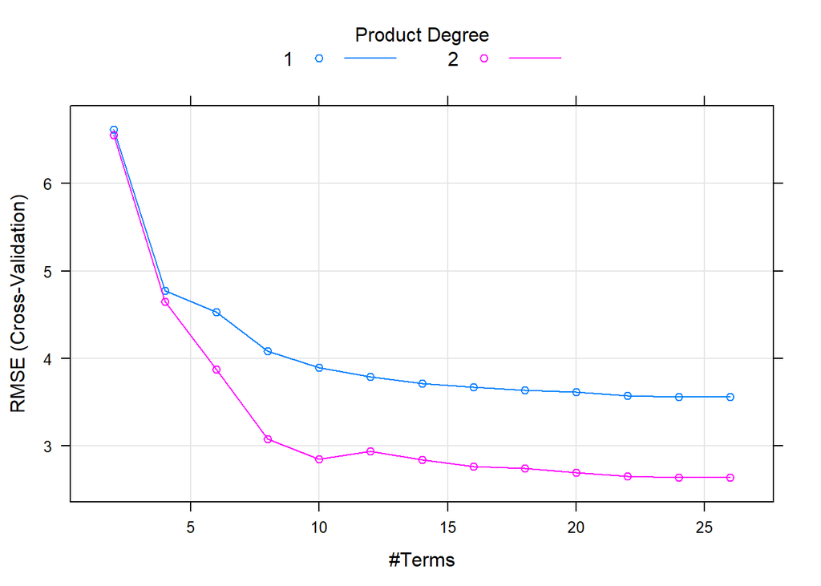

```r
plot(mars_mod)
```

```r
mars_mod$finalModel
```

```
## Selected 26 of 31 terms, and 19 of 114 predictors
## Termination condition: RSq changed by less than 0.001 at 31 terms
## Importance: plug_in_hybrid, year, eng_displ, start_stop, ...
## Number of terms at each degree of interaction: 1 10 15
## GCV 5.131003    RSS 17446.15    GRSq 0.9463657    RSq 0.9482507
```

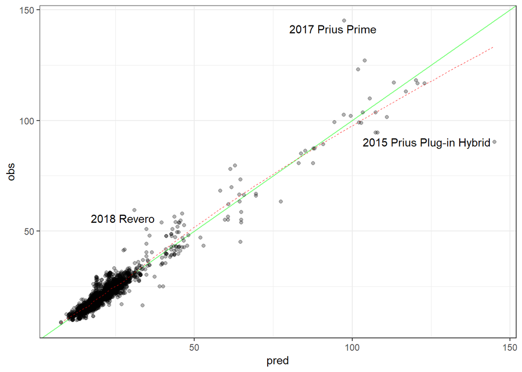

```r
obs_pred_plot(mars_mod, car_train)
```

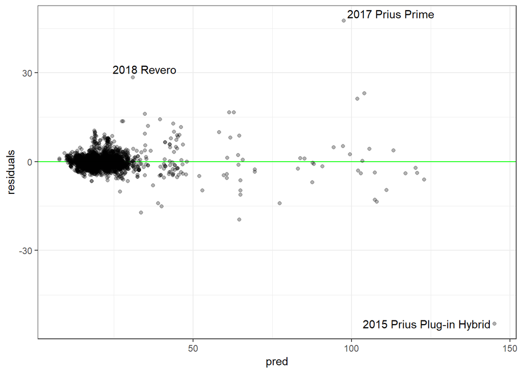

```r
resid_plot(mars_mod, car_train)
```

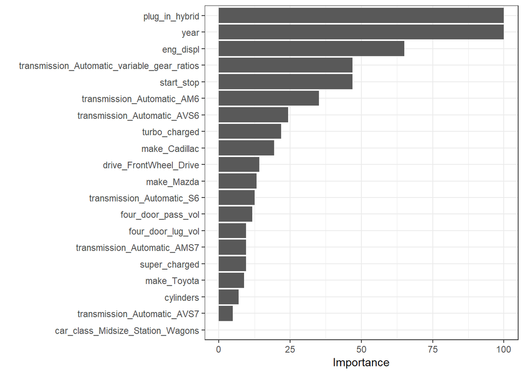

```r
mars_imp <- varImp(mars_mod)
ggplot(mars_imp, top = 20) + xlab("")
```

## Bayesian Model Comparison

Use the `resamples` method in `caret` to collect and collate cross-validation results.

```r
rs <- resamples(
  list(glmnet = glmn_mod, MARS = mars_mod)
)
```

The thing about this is that performance is correlated to resamples.

We’re going to fit a mixed-effects model to these resample results to compare the models.

There’s a built in function to do this.

```r
library(tidyposterior)
rmse_mod <- perf_mod(rs,
                     seed = 4344,
                     iter = 5000,
                     metric = "RMSE")
```

So to visualize this there’s *another* built in plotting function.

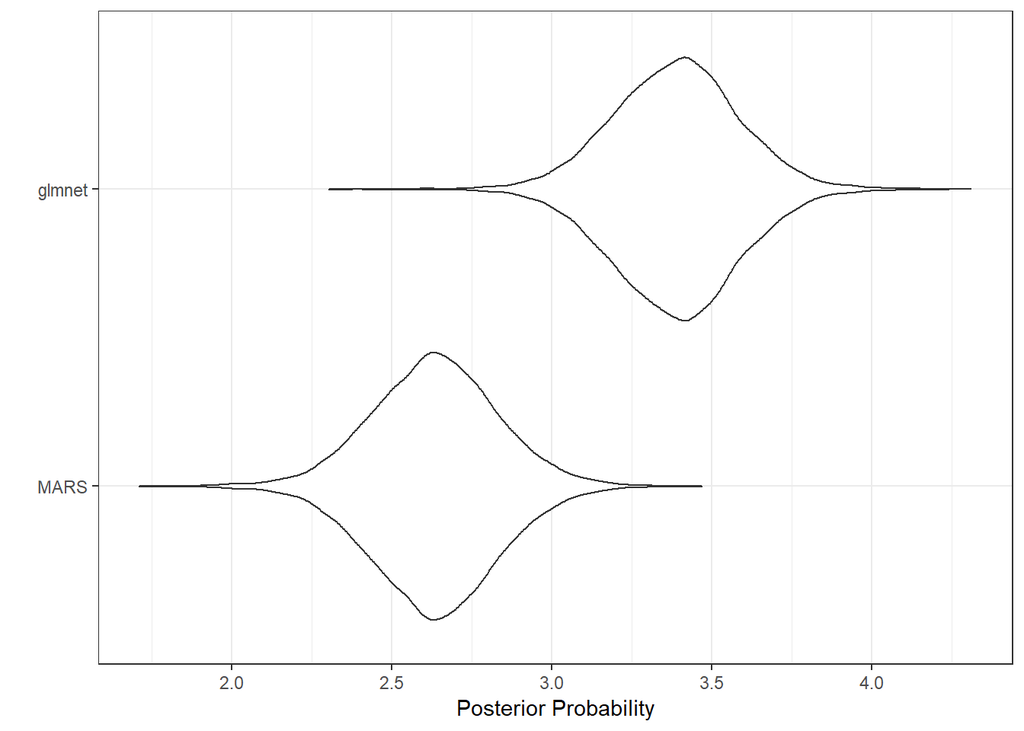

```r
posteriors <- tidy(rmse_mod, seed = 366784)
ggplot(posteriors) + coord_flip()
```

## Classification

Setup

```r
library(tidymodels)
```

`yardstick` contains helpful functions for analysis…

```r
two_class_example %>% conf_mat(truth = truth, estimate = predicted)
```

```
##           Truth
## Prediction Class1 Class2
##     Class1    227     50
##     Class2     31    192
```

```r
two_class_example %>% accuracy(truth = truth, estimate = predicted)
```

```
## # A tibble: 1 x 3
##   .metric  .estimator .estimate
##   <chr>    <chr>          <dbl>
## 1 accuracy binary         0.838
```

## OKCupid Data

```r
load("../data/okc.RData")
```